# Pruebas estadísticas iniciales

2026-03-30

Cargamos las librerías que vamos a utilizar

```r
library(urca)
library(tseries)
library(readr)
library(lmtest)
library(car)
datos <- read_csv("base_productividad.csv")
```

# Test de estacionariedad (Test de Dicky-Fuller)

Es necesario verificar previamente estacionariedad para evitar caer en regresiones espurias. Si las series son estacionarias, cualquier relación detectada es mucho más probable que sea real y no un accidente del paso del tiempo.

## Variable salario

1. Test ADF en niveles (Ho: Es No Estacionaria)

```r
ur_salario <- ur.df(datos$salario, type="trend", selectlags = "AIC", lags = 4)
summary(ur_salario)
```

```
##
## ###############################################
## # Augmented Dickey-Fuller Test Unit Root Test #
## ###############################################
##
## Test regression trend
##
##
## Call:
## lm(formula = z.diff ~ z.lag.1 + 1 + tt + z.diff.lag)
##
## Residuals:
##      Min       1Q   Median       3Q      Max
## -281.326  -19.154   -2.438   23.103  199.547
##
## Coefficients:
##               Estimate Std. Error t value Pr(>|t|)
## (Intercept) -230.42978  306.93616  -0.751  0.45619
## z.lag.1        0.08772    0.12571   0.698  0.48844
## tt             0.62952    0.67822   0.928  0.35760
## z.diff.lag1   -0.64965    0.19778  -3.285  0.00183 **
## z.diff.lag2   -0.38597    0.18473  -2.089  0.04158 *
## z.diff.lag3   -0.42798    0.17011  -2.516  0.01500 *
## z.diff.lag4    0.33487    0.14264   2.348  0.02273 *
## ---
## Signif. codes:  0 '***' 0.001 '**' 0.01 '*' 0.05 '.' 0.1 ' ' 1
##
## Residual standard error: 56.23 on 52 degrees of freedom
## Multiple R-squared:  0.8884, Adjusted R-squared:  0.8755
## F-statistic: 68.99 on 6 and 52 DF,  p-value: < 2.2e-16
##
##
## Value of test-statistic is: 0.6978 2.6314 2.5187
##
## Critical values for test statistics:
##       1pct  5pct 10pct
## tau3 -4.04 -3.45 -3.15
## phi2  6.50  4.88  4.16
## phi3  8.73  6.49  5.47
```

0.6978 > -3.45 (valor crítico a 5%) => No rechazas Ho => La serie es NO ESTACIONARIA

2. Como no es estacionaria, probamos con la primera diferencia (repetimos el test pero ahora con la serie diferenciada):

```r
ur_diff_salario <- ur.df(diff(datos$salario), type="drift", selectlags = "AIC", lags = 4)
summary(ur_diff_salario)
```

```
##
## ###############################################
## # Augmented Dickey-Fuller Test Unit Root Test #
## ###############################################
##
## Test regression drift
##
##
## Call:
## lm(formula = z.diff ~ z.lag.1 + 1 + z.diff.lag)
##
## Residuals:
##      Min       1Q   Median       3Q      Max
## -266.785  -24.232   -1.817   21.576  208.323
##
## Coefficients:
##             Estimate Std. Error t value Pr(>|t|)
## (Intercept)  13.8247     8.4987   1.627 0.109733
## z.lag.1      -1.4883     0.4275  -3.481 0.001008 **
## z.diff.lag1   0.0263     0.3333   0.079 0.937397
## z.diff.lag2  -0.1854     0.2353  -0.788 0.434072
## z.diff.lag3  -0.4592     0.1235  -3.717 0.000486 ***
## ---
## Signif. codes:  0 '***' 0.001 '**' 0.01 '*' 0.05 '.' 0.1 ' ' 1
##
## Residual standard error: 58.33 on 53 degrees of freedom
## Multiple R-squared:  0.9664, Adjusted R-squared:  0.9639
## F-statistic: 381.4 on 4 and 53 DF,  p-value: < 2.2e-16
##
##
## Value of test-statistic is: -3.481 6.0675
##
## Critical values for test statistics:
##       1pct  5pct 10pct
## tau2 -3.51 -2.89 -2.58
## phi1  6.70  4.71  3.86
```

Ahora sí se verifica que es estacionaria (se compara con -2.89 pq ya no estamos con tendencia). Por tanto, la variable original es integrada de orden uno, es decir, I(1).

## Variable pib

1. Test ADF en niveles (Ho: Es No Estacionaria)

```r
ur_pib <- ur.df(datos$pib, type="trend", selectlags = "AIC", lags = 4)
summary(ur_pib)
```

```
##
## ###############################################
## # Augmented Dickey-Fuller Test Unit Root Test #
## ###############################################
##
## Test regression trend
##
##
## Call:
## lm(formula = z.diff ~ z.lag.1 + 1 + tt + z.diff.lag)
##
## Residuals:
##      Min       1Q   Median       3Q      Max
## -20.6491  -0.5250   0.1011   0.7896  12.2765
##
## Coefficients:
##             Estimate Std. Error t value Pr(>|t|)
## (Intercept) -1.39441    1.26251  -1.104  0.27447
## z.lag.1     -0.48215    0.15505  -3.110  0.00304 **
## tt           0.07243    0.03776   1.918  0.06056 .
## z.diff.lag1  0.08023    0.14134   0.568  0.57273
## z.diff.lag2  0.21402    0.13877   1.542  0.12908
## z.diff.lag3  0.30412    0.13790   2.205  0.03188 *
## z.diff.lag4 -0.19993    0.13442  -1.487  0.14296
## ---
## Signif. codes:  0 '***' 0.001 '**' 0.01 '*' 0.05 '.' 0.1 ' ' 1
##
## Residual standard error: 4.028 on 52 degrees of freedom
## Multiple R-squared:  0.3694, Adjusted R-squared:  0.2967
## F-statistic: 5.078 on 6 and 52 DF,  p-value: 0.0003633
##
##
## Value of test-statistic is: -3.1096 3.2935 4.852
##
## Critical values for test statistics:
##       1pct  5pct 10pct
## tau3 -4.04 -3.45 -3.15
## phi2  6.50  4.88  4.16
## phi3  8.73  6.49  5.47
```

-3.1096 > -3.45 (valor crítico a 5%) => No rechazas Ho => La serie es NO ESTACIONARIA

2. Como no es estacionaria, probamos con la primera diferencia (repetimos el test pero ahora con la serie diferenciada):

```r
ur_diff_pib <- ur.df(diff(datos$pib), type="drift", selectlags = "AIC", lags = 4)
summary(ur_diff_pib)
```

```
##
## ###############################################
## # Augmented Dickey-Fuller Test Unit Root Test #
## ###############################################
##
## Test regression drift
##
##
## Call:
## lm(formula = z.diff ~ z.lag.1 + 1 + z.diff.lag)
##
## Residuals:
##      Min       1Q   Median       3Q      Max
## -19.0645  -0.8879   0.0124   0.7329  16.3403
##
## Coefficients:
##             Estimate Std. Error t value Pr(>|t|)
## (Intercept)   0.2557     0.5710   0.448  0.65616
## z.lag.1      -1.5534     0.2827  -5.495 1.14e-06 ***
## z.diff.lag1   0.3696     0.2477   1.492  0.14161
## z.diff.lag2   0.3416     0.1946   1.756  0.08487 .
## z.diff.lag3   0.4145     0.1234   3.358  0.00146 **
## ---
## Signif. codes:  0 '***' 0.001 '**' 0.01 '*' 0.05 '.' 0.1 ' ' 1
##
## Residual standard error: 4.338 on 53 degrees of freedom
## Multiple R-squared:  0.702,  Adjusted R-squared:  0.6795
## F-statistic: 31.21 on 4 and 53 DF,  p-value: 2.285e-13
##
##
## Value of test-statistic is: -5.495 15.1009
##
## Critical values for test statistics:
##       1pct  5pct 10pct
## tau2 -3.51 -2.89 -2.58
## phi1  6.70  4.71  3.86
```

Ahora sí se verifica que es estacionaria (se compara con -2.89 pq ya no estamos con tendencia). Por tanto, la variable original es integrada de orden uno, es decir, I(1).

## Variable productividad

1. Test ADF en niveles (Ho: Es No Estacionaria)

```r
ur_prod <- ur.df(datos$prod, type="trend", selectlags = "AIC", lags = 4)
summary(ur_prod)
```

```
##
## ###############################################
## # Augmented Dickey-Fuller Test Unit Root Test #
## ###############################################
##
## Test regression trend
##
##
## Call:
## lm(formula = z.diff ~ z.lag.1 + 1 + tt + z.diff.lag)
##
## Residuals:
##     Min      1Q  Median      3Q     Max
## -3.3434 -0.3014  0.0172  0.3336  2.3430
##
## Coefficients:
##             Estimate Std. Error t value Pr(>|t|)
## (Intercept)  1.11380    0.39854   2.795  0.00722 **
## z.lag.1     -0.36167    0.09265  -3.904  0.00027 ***
## tt          -0.02830    0.01000  -2.830  0.00657 **
## z.diff.lag1  0.20088    0.12733   1.578  0.12061
## z.diff.lag2  0.10455    0.12613   0.829  0.41088
## z.diff.lag3  0.43599    0.14173   3.076  0.00331 **
## ---
## Signif. codes:  0 '***' 0.001 '**' 0.01 '*' 0.05 '.' 0.1 ' ' 1
##
## Residual standard error: 0.9518 on 53 degrees of freedom
## Multiple R-squared:  0.2591, Adjusted R-squared:  0.1892
## F-statistic: 3.707 on 5 and 53 DF,  p-value: 0.00597
##
##
## Value of test-statistic is: -3.9037 5.171 7.6431
##
## Critical values for test statistics:
##       1pct  5pct 10pct
## tau3 -4.04 -3.45 -3.15
## phi2  6.50  4.88  4.16
## phi3  8.73  6.49  5.47
```

-3.9037 < -3.45 (valor crítico a 5%) => Rechazas Ho => La serie es ESTACIONARIA

## Variable paro

1. Test ADF en niveles (Ho: Es No Estacionaria)

```r
ur_paro <- ur.df(datos$paro, type="trend", selectlags = "AIC", lags = 4)
summary(ur_paro)
```

```
##
## ###############################################
## # Augmented Dickey-Fuller Test Unit Root Test #
## ###############################################
##
## Test regression trend
##
##
## Call:
## lm(formula = z.diff ~ z.lag.1 + 1 + tt + z.diff.lag)
##
## Residuals:
##      Min       1Q   Median       3Q      Max
## -1.05354 -0.35480  0.00573  0.36677  1.23637
##
## Coefficients:
##              Estimate Std. Error t value Pr(>|t|)
## (Intercept)  1.245575   0.763010   1.632   0.1086
## z.lag.1     -0.051182   0.027618  -1.853   0.0695 .
## tt          -0.011860   0.008548  -1.387   0.1712
## z.diff.lag1  0.125448   0.102851   1.220   0.2281
## z.diff.lag2 -0.082213   0.106386  -0.773   0.4432
## z.diff.lag3 -0.055794   0.110322  -0.506   0.6152
## z.diff.lag4  0.499135   0.104916   4.757  1.6e-05 ***
## ---
## Signif. codes:  0 '***' 0.001 '**' 0.01 '*' 0.05 '.' 0.1 ' ' 1
##
## Residual standard error: 0.5914 on 52 degrees of freedom
## Multiple R-squared:  0.4911, Adjusted R-squared:  0.4324
## F-statistic: 8.364 on 6 and 52 DF,  p-value: 2.317e-06
##
##
## Value of test-statistic is: -1.8532 1.8895 1.7173
##
## Critical values for test statistics:
##       1pct  5pct 10pct
## tau3 -4.04 -3.45 -3.15
## phi2  6.50  4.88  4.16
## phi3  8.73  6.49  5.47
```

-1.8532 > -3.45 (valor crítico a 5%) => No rechazas Ho => La serie es NO ESTACIONARIA

2. Como no es estacionaria, probamos con la primera diferencia (repetimos el test pero ahora con la serie diferenciada):

```r
ur_diff_paro <- ur.df(diff(datos$paro), type="drift", selectlags = "AIC", lags = 4)
summary(ur_diff_paro)
```

```
##
## ###############################################
## # Augmented Dickey-Fuller Test Unit Root Test #
## ###############################################
##
## Test regression drift
##
##
## Call:
## lm(formula = z.diff ~ z.lag.1 + 1 + z.diff.lag)
##
## Residuals:
##      Min       1Q   Median       3Q      Max
## -0.96321 -0.32227 -0.07156  0.30931  1.28704
##
## Coefficients:
##             Estimate Std. Error t value Pr(>|t|)
## (Intercept) -0.06297    0.06949  -0.906  0.36900
## z.lag.1     -0.38644    0.11359  -3.402  0.00129 **
## z.diff.lag1 -0.14743    0.12367  -1.192  0.23860
## z.diff.lag2 -0.14468    0.11834  -1.223  0.22699
## z.diff.lag3 -0.23277    0.10795  -2.156  0.03570 *
## z.diff.lag4  0.48157    0.10647   4.523 3.56e-05 ***
## ---
## Signif. codes:  0 '***' 0.001 '**' 0.01 '*' 0.05 '.' 0.1 ' ' 1
##
## Residual standard error: 0.5171 on 52 degrees of freedom
## Multiple R-squared:  0.7167, Adjusted R-squared:  0.6894
## F-statistic: 26.31 on 5 and 52 DF,  p-value: 3.815e-13
##
##
## Value of test-statistic is: -3.4021 6.0452
##
## Critical values for test statistics:
##       1pct  5pct 10pct
## tau2 -3.51 -2.89 -2.58
## phi1  6.70  4.71  3.86
```

Ahora sí se verifica que es estacionaria (se compara con -2.89 pq ya no estamos con tendencia). Por tanto, la variable original es integrada de orden uno, es decir, I(1).

# Test de cointegración de Engle-Granger

H0: No estacionarios residuos => No cointegración

Este test sirve para saber si existe una relación de equilibrio real a largo plazo o si la regresión es “espúrea” (falsa)

```r
modelo_lp <- lm(salario ~ prod + paro + pib, data = datos)
summary(modelo_lp)
```

```
##
## Call:
## lm(formula = salario ~ prod + paro + pib, data = datos)
##
## Residuals:
##     Min      1Q  Median      3Q     Max
## -332.17  -87.12   -3.90   70.55  421.18
##
## Coefficients:
##             Estimate Std. Error t value Pr(>|t|)
## (Intercept) 2660.341     88.977  29.899  < 2e-16 ***
## prod         -16.345     10.368  -1.577 0.120156
## paro          -4.299      4.749  -0.905 0.369020
## pib           13.225      3.564   3.711 0.000454 ***
## ---
## Signif. codes:  0 '***' 0.001 '**' 0.01 '*' 0.05 '.' 0.1 ' ' 1
##
## Residual standard error: 139.8 on 60 degrees of freedom
## Multiple R-squared:  0.3044, Adjusted R-squared:  0.2697
## F-statistic: 8.753 on 3 and 60 DF,  p-value: 6.661e-05
```

Extraemos los residuos (el error de equilibrio)

```r
residuos_lp <- residuals(modelo_lp)
```

Comprobamos si los residuos son estacionarios

```r
library(urca)
# Test ADF sobre los residuos (sin constante ni tendencia, type="none")
test_coint <- ur.df(residuos_lp, type = "none", selectlags = "BIC")
summary(test_coint)
```

```
##
## ###############################################
## # Augmented Dickey-Fuller Test Unit Root Test #
## ###############################################
##
## Test regression none
##
##
## Call:
## lm(formula = z.diff ~ z.lag.1 - 1 + z.diff.lag)
##
## Residuals:
##      Min       1Q   Median       3Q      Max
## -232.913  -39.137    5.992   57.740  208.402
##
## Coefficients:
##            Estimate Std. Error t value Pr(>|t|)
## z.lag.1    -0.19072    0.11541  -1.653    0.104
## z.diff.lag -0.76241    0.08874  -8.591 4.84e-12 ***
## ---
## Signif. codes:  0 '***' 0.001 '**' 0.01 '*' 0.05 '.' 0.1 ' ' 1
##
## Residual standard error: 85.68 on 60 degrees of freedom
## Multiple R-squared:  0.7154, Adjusted R-squared:  0.7059
## F-statistic:  75.4 on 2 and 60 DF,  p-value: < 2.2e-16
##
##
## Value of test-statistic is: -1.6525
##
## Critical values for test statistics:
##      1pct  5pct 10pct
## tau1 -2.6 -1.95 -1.61
```

Como -1.6525 > -1.95, NO RECHAZAMOS la hipótesis nula de raíz unitaria en los residuos. Esto indica que los residuos NO son estacionarios, por lo que las variables NO están cointegradas.

```r
# Modelo en primeras diferencias (Punto 4.7 de tu guía)
modelo_dif <- lm(diff(salario) ~ diff(pib) + diff(paro) + diff(prod), data = datos)
summary(modelo_dif)
```

```
##
## Call:
## lm(formula = diff(salario) ~ diff(pib) + diff(paro) + diff(prod),
##     data = datos)
##
## Residuals:
##     Min      1Q  Median      3Q     Max
## -194.68 -146.69   13.33  139.13  294.65
##
## Coefficients:
##             Estimate Std. Error t value Pr(>|t|)
## (Intercept)   12.992     20.076   0.647    0.520
## diff(pib)      6.151      5.329   1.154    0.253
## diff(paro)   -21.041     22.140  -0.950    0.346
## diff(prod)    -9.887     24.237  -0.408    0.685
##
## Residual standard error: 159.1 on 59 degrees of freedom
## Multiple R-squared:  0.04847,    Adjusted R-squared:  8.602e-05
## F-statistic: 1.002 on 3 and 59 DF,  p-value: 0.3985
```

```r
modelo_dif <- lm(diff(salario) ~ diff(pib) + diff(paro) + prod[-1], data = datos)

summary(modelo_dif)
```

```
##
## Call:
## lm(formula = diff(salario) ~ diff(pib) + diff(paro) + prod[-1],
##     data = datos)
##
## Residuals:
##     Min      1Q  Median      3Q     Max
## -192.85 -147.78   12.53  137.12  294.57
##
## Coefficients:
##             Estimate Std. Error t value Pr(>|t|)
## (Intercept)   13.907     20.804   0.668    0.506
## diff(pib)      4.983      4.446   1.121    0.267
## diff(paro)   -22.783     21.988  -1.036    0.304
## prod[-1]      -1.019     10.383  -0.098    0.922
##
## Residual standard error: 159.3 on 59 degrees of freedom
## Multiple R-squared:  0.04594,    Adjusted R-squared:  -0.00257
## F-statistic: 0.947 on 3 and 59 DF,  p-value: 0.4238
```

Punto 5. “Endogeneidad”: Las instrucciones sugieren que si la teoría lo justifica, usemos retardos como instrumentos. Es muy probable que el salario no reaccione al PIB de hoy, sino al de hace uno o dos trimestres.

# Modelo con retardos

```r
# 1. Convertimos a objeto de serie temporal para usar lags fácilmente
pib_ts <- ts(datos$pib, frequency = 4)
salario_ts <- ts(datos$salario, frequency = 4)
paro_ts <- ts(datos$paro, frequency = 4)
prod_ts <- ts(datos$prod, frequency = 4)

# 2. Creamos las diferencias y los retardos (Lag -1 es un retraso de un periodo)
d_salario <- diff(salario_ts)
d_pib_lag1 <- stats::lag(diff(pib_ts), -1)
d_paro_lag1 <- stats::lag(diff(paro_ts), -1)
d_prod_lag1 <- stats::lag(diff(prod_ts), -1)

# 3. Sincronizamos las series para que tengan la misma longitud
datos_reg <- ts.intersect(d_salario, d_pib_lag1, d_paro_lag1, d_prod_lag1)

# 4. Nuevo modelo con efecto retardado
modelo_retardado <- lm(d_salario ~ d_pib_lag1 + d_paro_lag1 + d_prod_lag1, data = datos_reg)
summary(modelo_retardado)
```

```
##
## Call:
## lm(formula = d_salario ~ d_pib_lag1 + d_paro_lag1 + d_prod_lag1,
##     data = datos_reg)
##
## Residuals:
##    Min     1Q Median     3Q    Max
## -219.5 -145.0  -28.1  136.5  241.0
##
## Coefficients:
##             Estimate Std. Error t value Pr(>|t|)
## (Intercept)   11.429     20.519   0.557    0.580
## d_pib_lag1    -3.973      5.403  -0.735    0.465
## d_paro_lag1   14.714     22.450   0.655    0.515
## d_prod_lag1   24.537     24.573   0.999    0.322
##
## Residual standard error: 161.3 on 58 degrees of freedom
## Multiple R-squared:  0.0327, Adjusted R-squared:  -0.01734
## F-statistic: 0.6535 on 3 and 58 DF,  p-value: 0.584
```

```r
library(lmtest)
dwtest(modelo_retardado)
```

```
##
##  Durbin-Watson test
##
## data:  modelo_retardado
## DW = 3.5778, p-value = 1
## alternative hypothesis: true autocorrelation is greater than 0
```

Sí hay autocorrelación (negativa)

# Regresión con corrección de autocorrelación

```r
library(nlme)

# Estimación por MCG (Mínimos Cuadrados Generalizados) con proceso AR(1)
# Esto es exactamente lo que pide el punto 4.7 de tu guía.
modelo_mcg <- gls(d_salario ~ d_pib_lag1 + d_paro_lag1 + d_prod_lag1,
                  data = as.data.frame(datos_reg),
                  correlation = corAR1(form = ~ 1), # Especificamos el AR(1)
                  method = "ML")

summary(modelo_mcg)
```

```
## Generalized least squares fit by maximum likelihood
##   Model: d_salario ~ d_pib_lag1 + d_paro_lag1 + d_prod_lag1
##   Data: as.data.frame(datos_reg)
##        AIC      BIC    logLik
##   724.4724 737.2352 -356.2362
##
## Correlation Structure: AR(1)
##  Formula: ~1
##  Parameter estimate(s):
##        Phi
## -0.8855839
##
## Coefficients:
##                  Value Std.Error   t-value p-value
## (Intercept)  11.407882  5.273700  2.163165  0.0347
## d_pib_lag1   -2.508244  2.395316 -1.047145  0.2994
## d_paro_lag1 -12.997742  6.952939 -1.869388  0.0666
## d_prod_lag1  19.520005  9.322363  2.093890  0.0407
##
##  Correlation:
##             (Intr) d_pb_1 d_pr_l1
## d_pib_lag1  -0.080
## d_paro_lag1 -0.067  0.365
## d_prod_lag1  0.089 -0.641 -0.297
##
## Standardized residuals:
##        Min         Q1        Med         Q3        Max
## -1.2933236 -0.9346878 -0.1168122  0.8794724  1.5521285
##
## Residual standard error: 160.9794
## Degrees of freedom: 62 total; 58 residual
```

Al aplicar Mínimos Cuadrados Generalizados (MCG), hemos corregido la estructura del error y ahora aparecen variables estadísticamente significativas

# Test de causalidad de Granger

H0: Los valores pasados de X no ayudan a predecir el valor de Y

¿La productividad causa realmente al salario?

```r
library(lmtest)
grangertest(d_salario ~ d_prod_lag1, order = 1, data = datos_reg)
```

```
## Granger causality test
##
## Model 1: d_salario ~ Lags(d_salario, 1:1) + Lags(d_prod_lag1, 1:1)
## Model 2: d_salario ~ Lags(d_salario, 1:1)
##   Res.Df Df      F Pr(>F)
## 1     58
## 2     59 -1 0.0696 0.7928
```

La productividad no ayuda a predecir el salario mejor de lo que lo hace el propio pasado del salario por sí solo.

# Pruebas de diagnóstico (modelo final)

Normalidad de residuos

```r
# Extraemos los residuos ponderados (los "limpios")
res_finales <- residuals(modelo_mcg, type = "normalized")

# Test de Shapiro con los residuos correctos
shapiro.test(res_finales)
```

```
##
##  Shapiro-Wilk normality test
##
## data:  res_finales
## W = 0.91592, p-value = 0.0004211
```

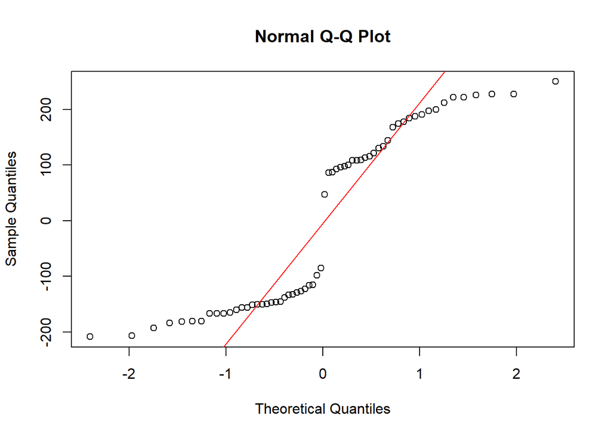

```r
# Gráfico de Probabilidad Normal
qqnorm(residuals(modelo_mcg))
qqline(residuals(modelo_mcg), col = "red")
```

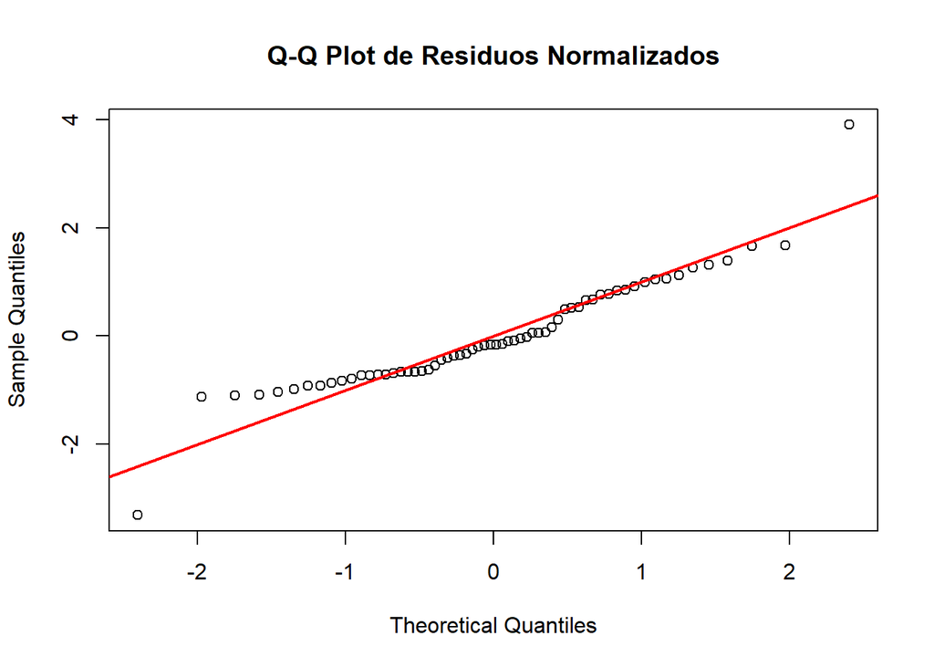

```r
# Gráfico con residuos estandarizados (es más preciso para diagnóstico)
residuos_std <- residuals(modelo_mcg, type = "normalized")
qqnorm(residuos_std, main = "Q-Q Plot de Residuos Normalizados")
qqline(residuos_std, col = "red", lwd = 2)
```

Homocedasticidad (Breusch-Pagan)

```r
# 1. Extraemos los residuos limpios de autocorrelacion y heterocedasticidad
residuos_p <- residuals(modelo_mcg, type = "normalized")

# 2. Creamos un modelo lineal "ficticio" usando esos residuos como Y
# Esto le permite a bptest saber qué variables explicativas usar
modelo_para_test <- lm(residuos_p ~ d_pib_lag1 + d_paro_lag1 + d_prod_lag1, data = as.data.frame(datos_reg))

# 3. Aplicamos el test directamente sobre ese modelo
library(lmtest)
bptest(modelo_para_test)
```

```
##
##  studentized Breusch-Pagan test
##
## data:  modelo_para_test
## BP = 11.256, df = 3, p-value = 0.01042
```

Multicolinealidad (VIF)

```r
vif(modelo_mcg)
```

```
##  d_pib_lag1 d_paro_lag1 d_prod_lag1
##    1.800971    1.163021    1.711583
```